# Predictive modeling and Regression analysis on adult census income data

# 5. Data preprocessing

## 5.1. Exploratory data analysis

In the exploratory analysis for predicting hours per week, the initial assessment of numeric features—final weight, capital gain, and capital loss—has provided crucial insights. Regarding final weight, the scatter plot showcases a nearly horizontal slope vs. hours per week. This pattern indicates a weak correlation, suggesting that final weight has limited influence on hours per week. Consequently, this feature will be excluded from subsequent analyses due to its minimal impact on predicting hours worked per week. Conversely, both capital gain and capital loss exhibit a positive slope in their respective scatter plots concerning hours per week. This positive trend signifies a notable correlation between these variables and hours worked per week. As a result, these features will be retained for further analysis, considering their apparent association with the target variable, hours per week.

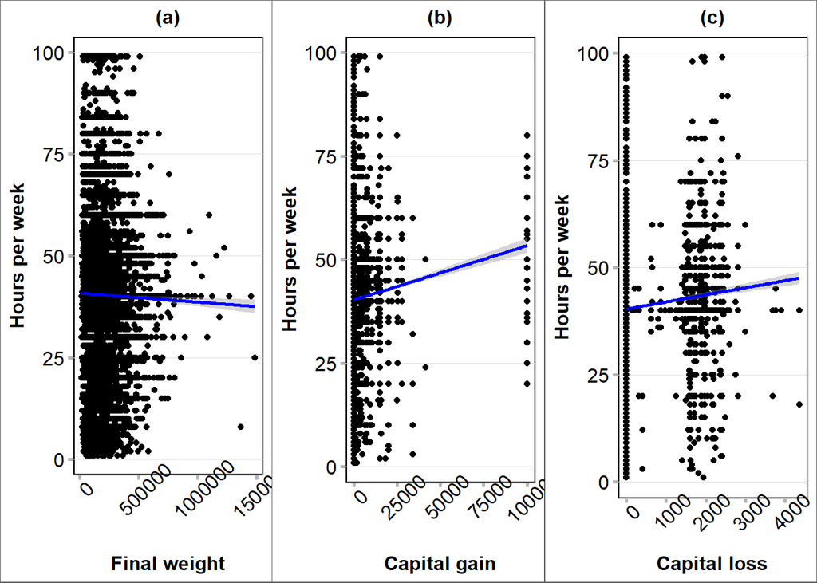

1. Scatter plots of numeric features againts Hours per week

The box plot analysis conducted on hours per week across different categories within categorical features has yielded important insights. The variation in the distribution of hours per week among different categories within each categorical feature implies a distinct influence (association) of these categories on the target variable. This observed association between categorical features and hours per week signifies that these categorical variables hold relevance in explaining the variation in hours worked per week. Consequently, all categorical features will proceed for encoding (one hot encoding), ensuring the incorporation of each category as dummy variable into the modeling process to capture their influence on predicting hours per week accurately.

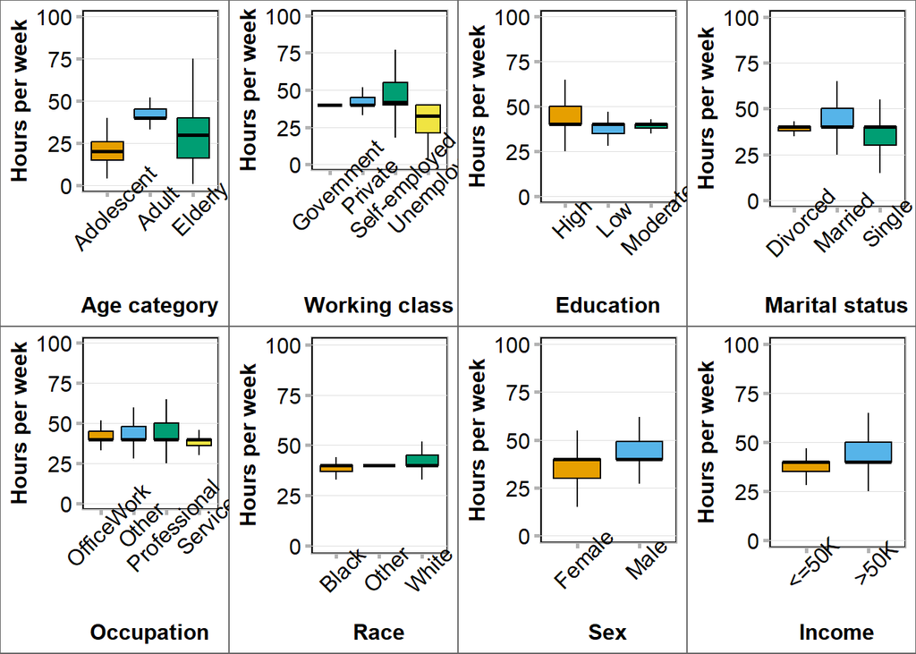

2. Box plot to observe the association between categorical features and Hours per week